# Making predictions

## Let's think about smooths first

### Uncertainty in smooths

- Dashed lines are +/- 2 standard errors
- How do we translate to \( \hat{N} \)?

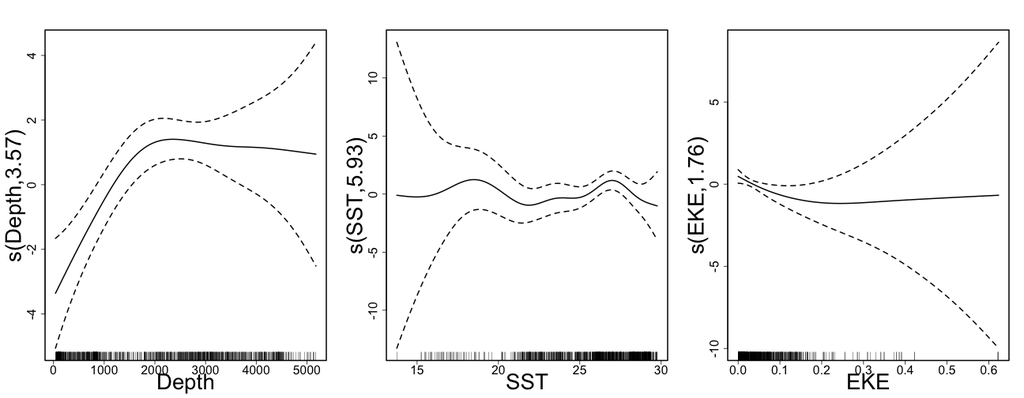

### Back to bases

- Before we expressed smooths as:
  - \( s(x) = \sum_{k=1}^K \beta_k b_k(x) \)
- Theory tells us that:
  - \( \boldsymbol{\beta} \sim N(\boldsymbol{\hat{\beta}}, \mathbf{V}_\boldsymbol{\beta}) \)
  - where \( \mathbf{V}_\boldsymbol{\beta} \) is a bit complicated
  - (derived from the smoother matrix)

### Predictions to prediction variance (roughly)

- “map” data onto fitted values \( \mathbf{X}\boldsymbol{\beta} \)
- “map” prediction matrix to predictions \( \mathbf{X}_p \boldsymbol{\beta} \)
- Here \( \mathbf{X}_p \) need to take smooths into account
- pre-/post-multiply by \( \mathbf{X}_p \) to “transform variance”
  - \( \Rightarrow \mathbf{X}_p^\text{T}\mathbf{V}_\boldsymbol{\beta} \mathbf{X}_p \)
  - link scale, need to do another transform for response

## Adding in detection functions

### GAM + detection function uncertainty

(Getting a little fast-and-loose with the mathematics)

\[ \text{CV}^2\left( \hat{N} \right) \approx \text{CV}^2\left( \text{GAM} \right) +\\ \text{CV}^2\left( \text{detection function}\right) \]

### Not that simple...

- Assumes detection function and GAM are **independent**
- **Maybe** this is okay?
- (Probably not true?)

### Variance propagation

- Include the detectability as term in GAM
- Random effect, mean zero, variance of detection function
- Uncertainty “propagated” through the model
- Details in bibliography (too much to detail here)
- Under development
- (Can cover in special topic)

## That seemed complicated...

## R to the rescue

### In R...

- Functions in `dsm` to do this
- `dsm.var.gam`
  - assumes spatial model and detection function are independent
- `dsm.var.prop`
  - propagates uncertainty from detection function to spatial model
  - only works for `count` models (more or less)

### Variance of abundance

Using `dsm.var.gam`

```r
dsm_tw_var_ind <- dsm.var.gam(dsm_all_tw_rm, predgrid,
                              off.set=predgrid$off.set)
summary(dsm_tw_var_ind)
```

```
Summary of uncertainty in a density surface model calculated
 analytically for GAM, with delta method

Approximate asymptotic confidence interval:
    2.5%     Mean    97.5%
1539.018 2491.864 4034.643
(Using log-Normal approximation)

Point estimate                 : 2491.864
CV of detection function       : 0.2113123
CV from GAM                    : 0.1329
Total standard error           : 622.0389
Total coefficient of variation : 0.2496
```

### Variance of abundance

Using `dsm.var.prop`

```r
dsm_tw_var <- dsm.var.prop(dsm_all_tw_rm, predgrid,
                           off.set=predgrid$off.set)
summary(dsm_tw_var)
```

```
Summary of uncertainty in a density surface model calculated
 by variance propagation.

Probability of detection in fitted model and variance model
  Fitted.model Fitted.model.se Refitted.model
1    0.3624567      0.07659373      0.3624567

Approximate asymptotic confidence interval:
    2.5%     Mean    97.5%
1556.898 2458.634 3882.646
(Using log-Normal approximation)

Point estimate                 : 2458.634
Standard error                 : 581.0379
Coefficient of variation       : 0.2363
```

### Plotting - data processing

- Calculate uncertainty per-cell
- `dsm.var.*` thinks `predgrid` is one “region”
- Need to split data into cells (using `split()`)
- (Could be arbitrary sets of cells, see exercises)
- Need `width` and `height` of cells for plotting

### Plotting (code)

```r
predgrid$width <- predgrid$height <- 10*1000
predgrid_split <- split(predgrid, 1:nrow(predgrid))
head(predgrid_split,3)
```

```
$`1`
           x      y    Depth    SST      NPP DistToCAS    EKE off.set
126 547984.6 788254 153.5983 8.8812 1462.521  11788.97 0.0074   1e+08
    LinkID    Nhat_tw height width
126      1 0.01417657  10000 10000

$`2`
           x      y    Depth    SST     NPP DistToCAS    EKE off.set
127 557984.6 788254 552.3107 9.2078 1465.41  5697.248 0.0144   1e+08
    LinkID    Nhat_tw height width
127      2 0.05123483  10000 10000

$`3`
           x      y   Depth    SST      NPP DistToCAS    EKE off.set
258 527984.6 778254 96.8199 9.6341 1429.432  13722.63 0.0024   1e+08
    LinkID    Nhat_tw height width
258      3 0.01118858  10000 10000
```

```r
dsm_tw_var_map <- dsm.var.prop(dsm_all_tw_rm, predgrid_split,
                               off.set=predgrid$off.set)
```

### CV plot

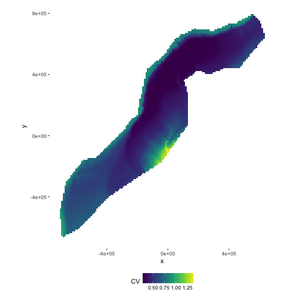

```
p <- plot(dsm_tw_var_map, observations=FALSE, plot=FALSE) +
      coord_equal() +
      scale_fill_viridis()
print(p)
```

### Interpreting CV plots

- Plotting coefficient of variation
- Standardise standard deviation by mean
- \( \text{CV} = \text{se}(\hat{N})/\hat{N} \) (per cell)
- Can be useful to overplot survey effort

### Effort overplotted

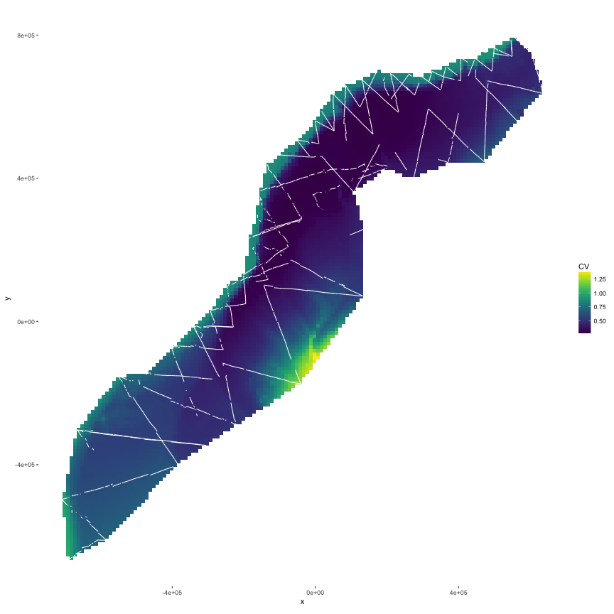

### Big CVs

- Here CVs are “well behaved”
- Not always the case (huge CVs possible)
- These can be a pain to plot
- Use `cut()` in R to make categorical variable
  - e.g. `c(seq(0,1, len=100), 2:4, Inf)` or somesuch

### Recap

- How does uncertainty arise in a DSM?
- Estimate variance of abundance estimate
- Map coefficient of variation